# Elaboração de Gráficos com o Pacote ggplot2

Rafael de Freitas Souza

Para a elaboração de gráficos, utilizaremos as funções do pacote ggplot2. Em regra, essas funções são de fácil assimilação após pouco tempo de treino.

De modo geral, a elaboração de um gráfico com o pacote ggplot2 não costuma ser uma tarefa difícil, desde que o aluno tenha em mente três coisas:

- Uma ideia clara de qual gráfico se quer elaborar;
- O entendimento de que as funções do pacote ggplot2 construirão um gráfico a partir de, necessariamente, um data frame;
- A compreensão de que sempre deverá ser comandada, no mínimo, um tipo de geometria.

Obviamente, a depender das razões do discente, pode haver gráficos que dependerão de um nível alto de erudição no R. Porém, para a maior das necessidades desse curso, o aluno encontrará soluções interessantes nos códigos abaixo.

Dito isso, vamos comandar os pacotes necessários para essa aula:

```r
library(tidyverse)
library(plotly)
library(ggrepel)
library(PerformanceAnalytics)
library(reshape2)
```

# Gráfico de Barras

Vamos carregar nossa base de dados que será utilizada para a construção de um gráfico de barras.

```r
load("perfil_investidor.RData")
```

Aplicando a sintaxe básica do ggplot2 à base de dados:

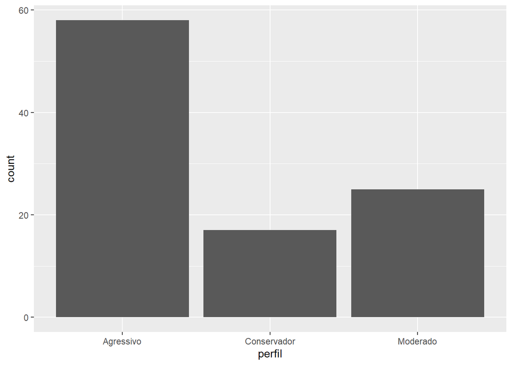

Note que a nomenclatura dos perfis foi ordenada de forma alfabética. Para alterar a situação, podemos utilizar a função factor(), para redefinir a ordem dos levels:

```r
perfil_investidor$perfil <- factor(perfil_investidor$perfil,
                                   levels = c("Conservador",
                                              "Moderado",
                                              "Agressivo"))
```

Utilizando, mais uma vez, a sintaxe básica do ggplot2 à base de dados:

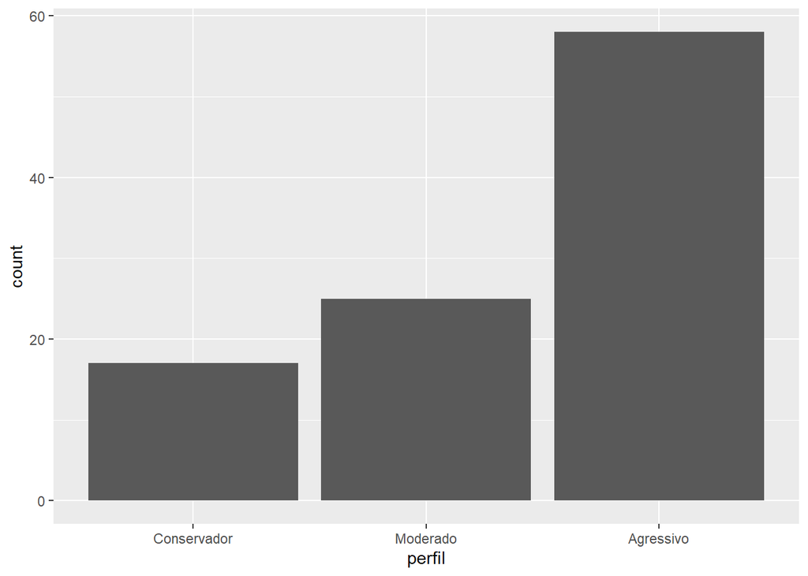

```r
ggplot(data = perfil_investidor) +
  geom_bar(aes(x = perfil))
```

Adicionando informações ao nosso gráfico:

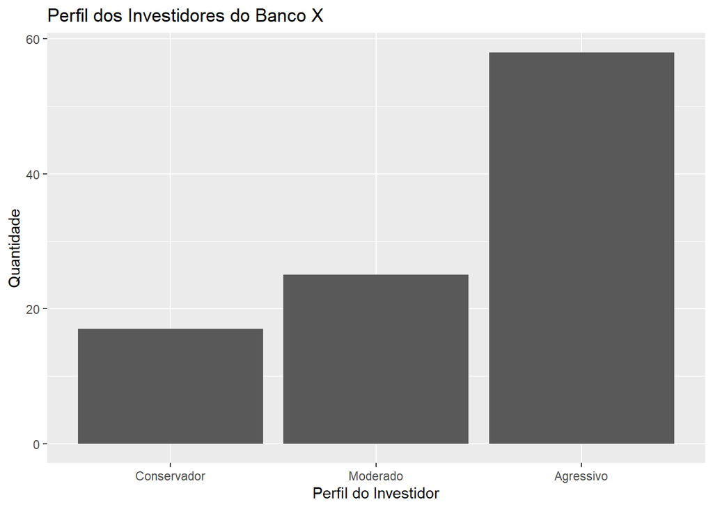

```r
ggplot(data = perfil_investidor) +
  geom_bar(aes(x = perfil)) +
  labs(title = "Perfil dos Investidores do Banco X",
       x = "Perfil do Investidor",
       y = "Quantidade")
```

Adicionando detalhamentos ao gráfico:

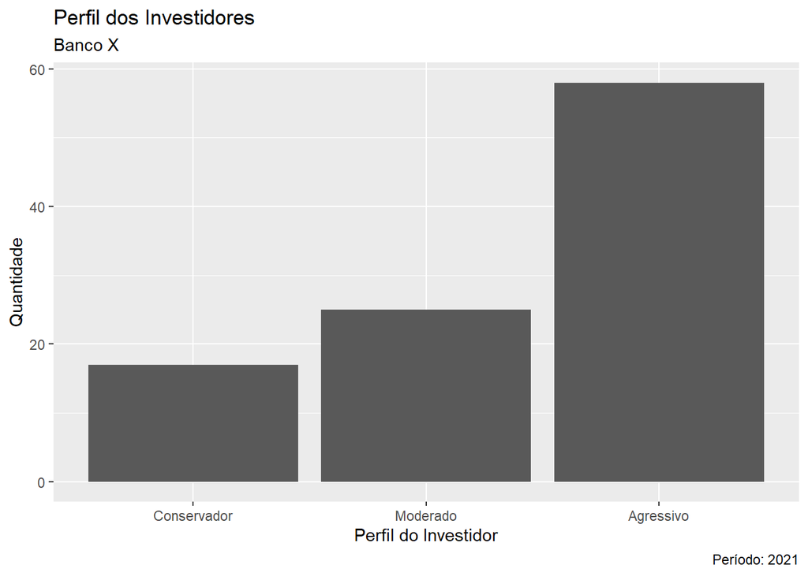

```r
ggplot(data = perfil_investidor) +
  geom_bar(aes(x = perfil)) +
  labs(title = "Perfil dos Investidores",
       subtitle = "Banco X",
       x = "Perfil do Investidor",
       y = "Quantidade",
       caption = "Período: 2021")
```

Adicionando cores à plotagem:

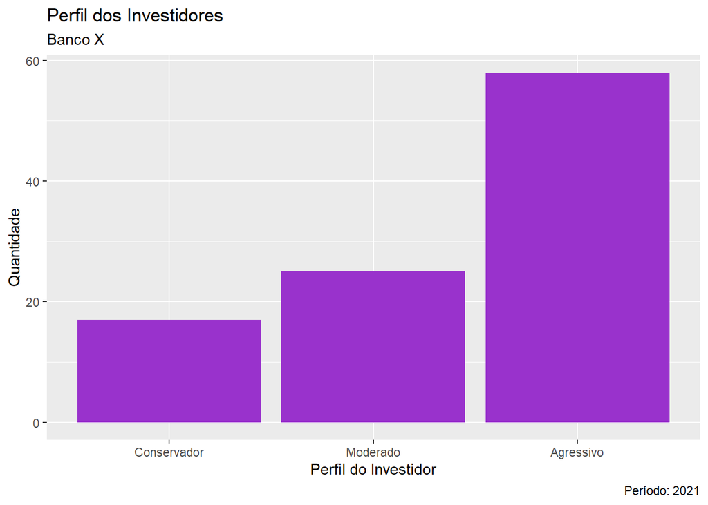

```r
ggplot(data = perfil_investidor) +
  geom_bar(aes(x = perfil), fill = "darkorchid") +
  labs(title = "Perfil dos Investidores",
       subtitle = "Banco X",
       x = "Perfil do Investidor",
       y = "Quantidade",
       caption = "Período: 2021")
```

Para verificar as cores possíveis de serem declaradas com a linguagem básica do R, podemos acessar o seguinte sítio eletrônico:

[Espécie de catálogo de cores para gráficos no R](http://www.stat.columbia.edu/~tzheng/files/Rcolor.pdf)

Alterando as cores:

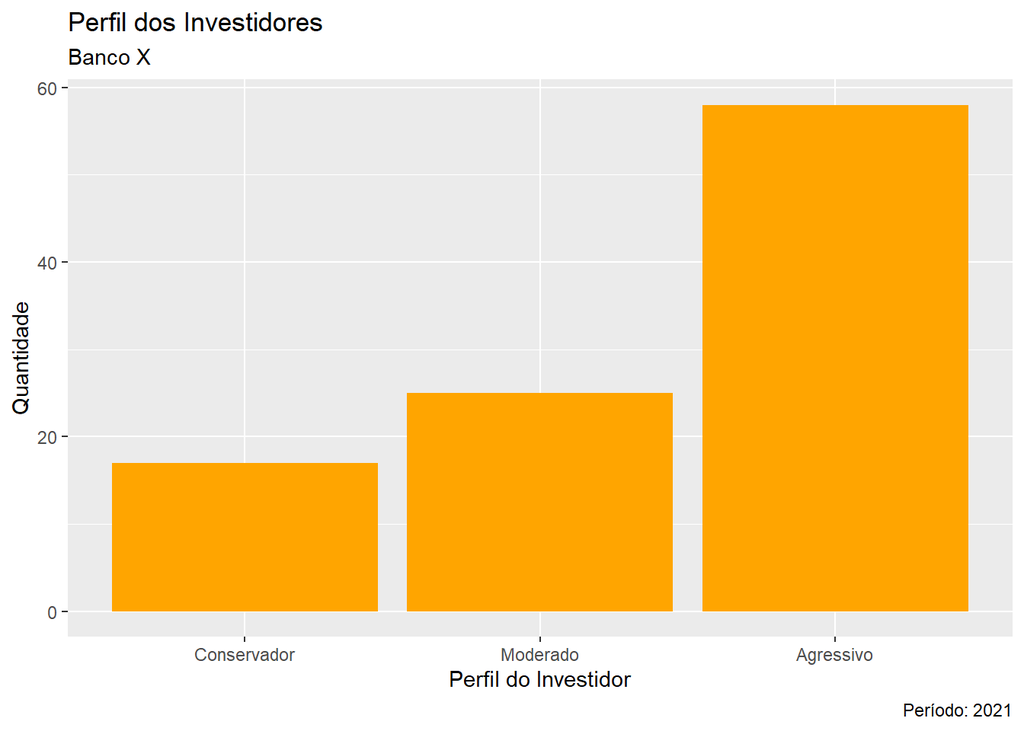

```r
ggplot(data = perfil_investidor) +
  geom_bar(aes(x = perfil), fill = "orange") +
  labs(title = "Perfil dos Investidores",
       subtitle = "Banco X",
       x = "Perfil do Investidor",
       y = "Quantidade",
       caption = "Período: 2021")
```

Adicionando bordas:

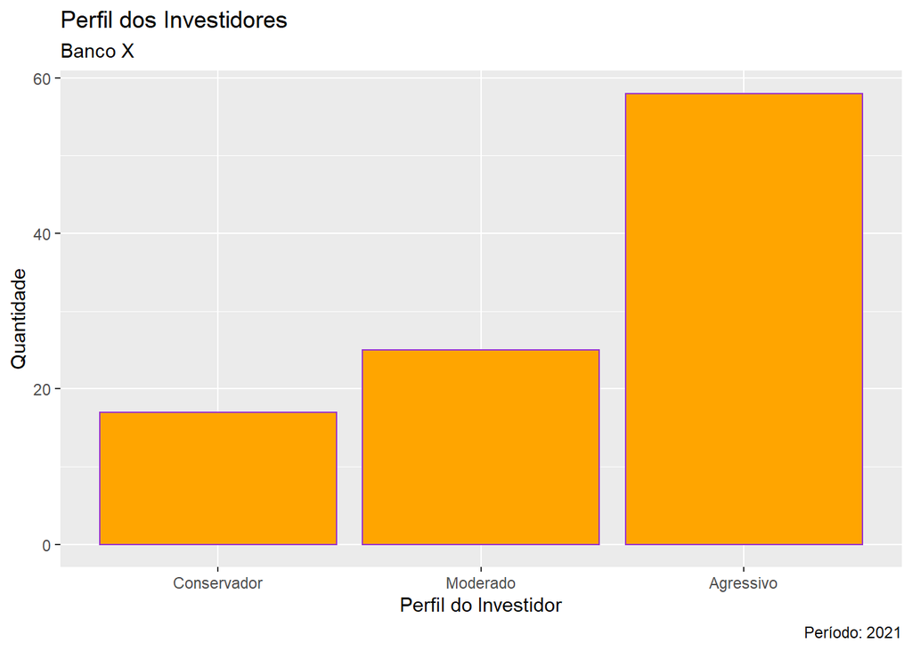

```r
ggplot(data = perfil_investidor) +
  geom_bar(aes(x = perfil), color = "darkorchid", fill = "orange") +
  labs(title = "Perfil dos Investidores",
       subtitle = "Banco X",
       x = "Perfil do Investidor",
       y = "Quantidade",
       caption = "Período: 2021")
```

Modificando o fundo dos gráficos:

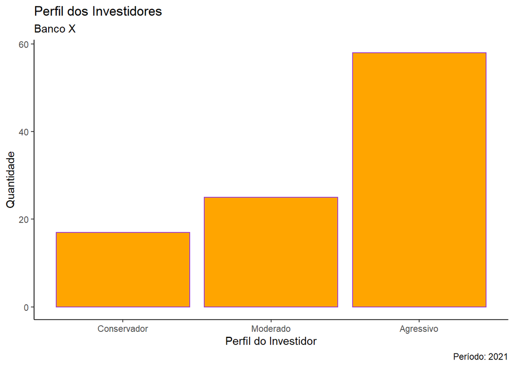

```r
ggplot(data = perfil_investidor) +
  geom_bar(aes(x = perfil), color = "darkorchid", fill = "orange") +
  labs(title = "Perfil dos Investidores",
       subtitle = "Banco X",
       x = "Perfil do Investidor",
       y = "Quantidade",
       caption = "Período: 2021") +
  theme_classic()
```

Adicionando labels:

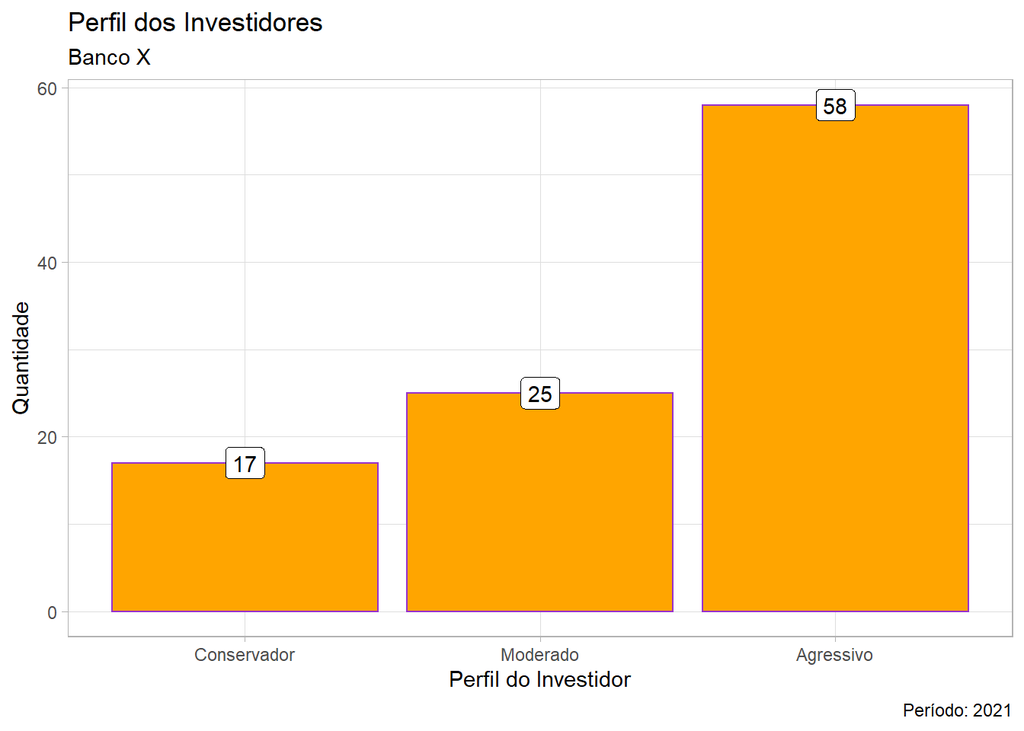

```r
ggplot(data = perfil_investidor) +
  geom_bar(aes(x = perfil), color = "darkorchid", fill = "orange") +
  geom_label(aes(x = perfil, label = ..count..), stat = "count") +
  labs(title = "Perfil dos Investidores",
       subtitle = "Banco X",
       x = "Perfil do Investidor",
       y = "Quantidade",
       caption = "Período: 2021") +
  theme_light()
```

Reposicionando as labels:

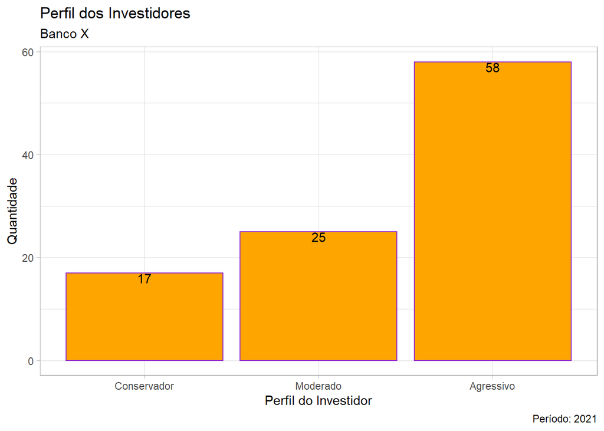

```r
ggplot(data = perfil_investidor) +
  geom_bar(aes(x = perfil), color = "darkorchid", fill = "orange") +
  geom_text(aes(x = perfil, label = ..count..),
            stat = "count", vjust = 1) +
  labs(title = "Perfil dos Investidores",
       subtitle = "Banco X",
       x = "Perfil do Investidor",
       y = "Quantidade",
       caption = "Período: 2021") +
  theme_light()
```

Rotacionando um gráfico:

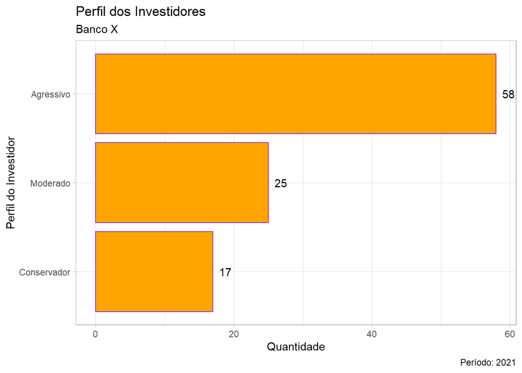

```r
ggplot(data = perfil_investidor) +
  geom_bar(aes(x = perfil), color = "darkorchid", fill = "orange") +
  geom_text(aes(x = perfil, label = ..count..), stat = "count", hjust = -0.5) +
  labs(title = "Perfil dos Investidores",
       subtitle = "Banco X",
       x = "Perfil do Investidor",
       y = "Quantidade",
       caption = "Período: 2021") +
  coord_flip() +
  theme_light()
```

Invertendo as ordens das categorias:

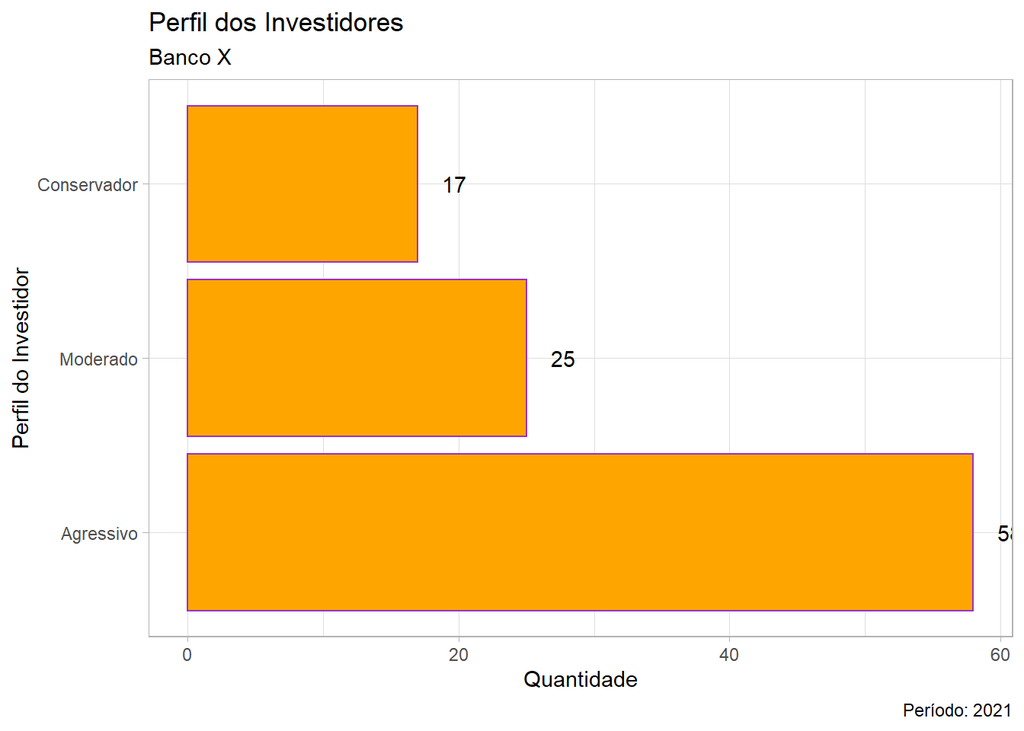

```r
ggplot(data = perfil_investidor) +
  geom_bar(aes(x = fct_rev(perfil)), color = "darkorchid", fill = "orange") +
  geom_text(aes(x = perfil, label = ..count..),
            stat = "count", hjust = -1) +
  labs(title = "Perfil dos Investidores",
       subtitle = "Banco X",
       x = "Perfil do Investidor",
       y = "Quantidade",
       caption = "Período: 2021") +
  coord_flip() +
  theme_light()
```

# Histograma

Vamos utilizar alguns dados sobre os municípios de São Paulo para essa nova demanda:

```r
load("dados_sp.RData")
```

Aplicando a sintaxe básica do ggplot2:

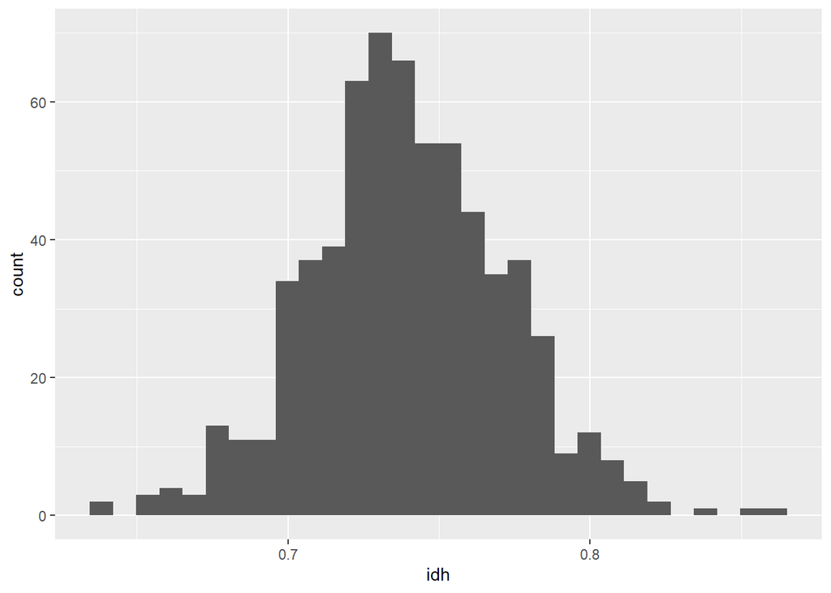

```r
ggplot(data = dados_sp) +
  geom_histogram(aes(x = idh))
```

Colorindo o gráfico:

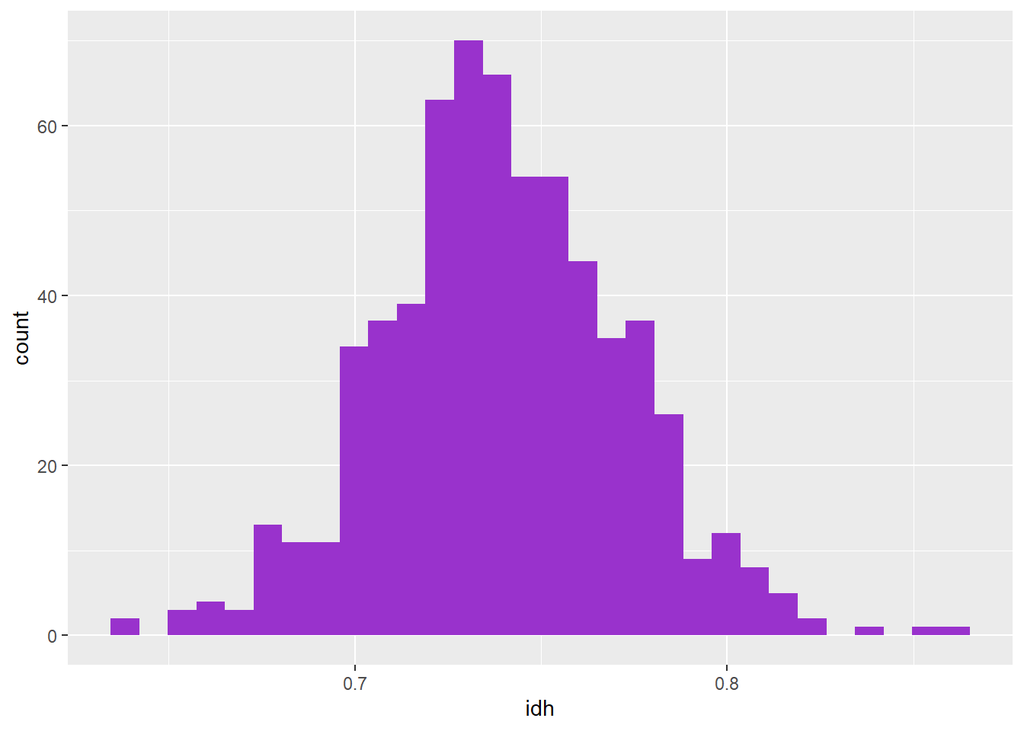

```r
ggplot(data = dados_sp) +
  geom_histogram(aes(x = idh), fill = "darkorchid")
```

Alterando o plano de fundo:

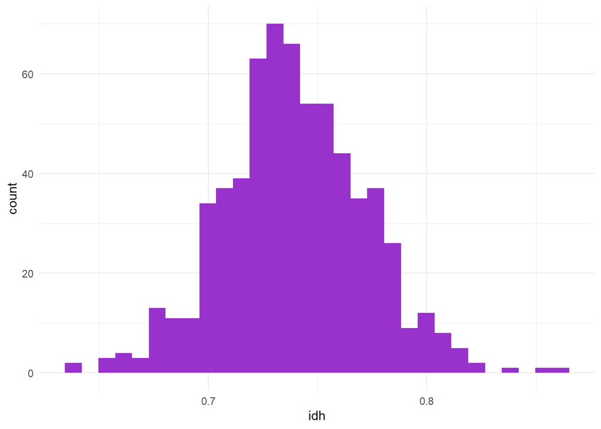

```r
ggplot(data = dados_sp) +
  geom_histogram(aes(x = idh), fill = "darkorchid") +
  theme_minimal()
```

Adicionando contornos e nomes dos eixos:

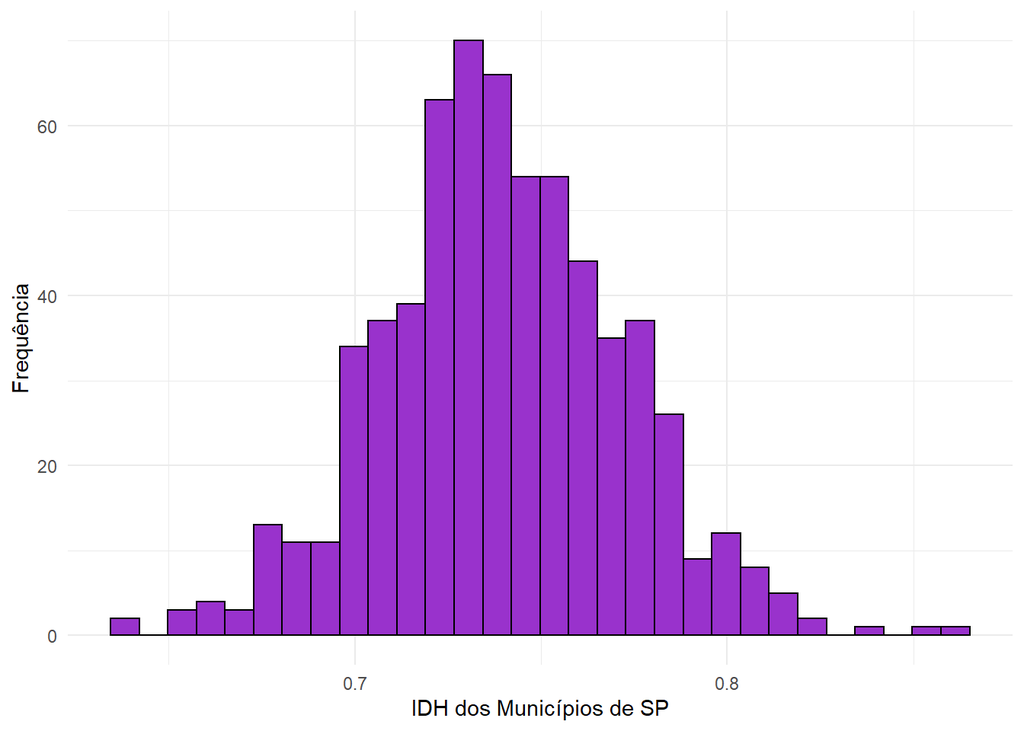

```r
ggplot(data = dados_sp) +
  geom_histogram(aes(x = idh), fill = "darkorchid", color = "black") +
  labs(x = "IDH dos Municípios de SP",
       y = "Frequência") +
  theme_minimal()
```

Alterando a quantidade de caixas do histograma:

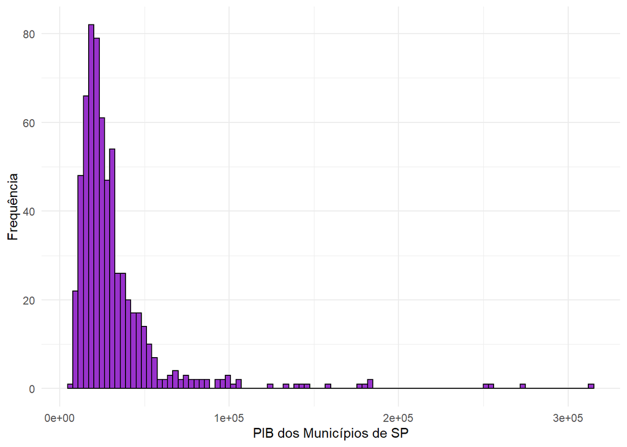

```r
ggplot(data = dados_sp) +
  geom_histogram(aes(x = pib), fill = "darkorchid",
                 color = "black", bins = 100) +
  labs(x = "PIB dos Municípios de SP",
       y = "Frequência") +
  theme_minimal()
```

# Gráfico de Pontos

Para esse desafio, utilizaremos dados sobre os bairros da capital de São Paulo:

```r
load("atlas_ambiental.RData")
```

Aplicando a sintaxe básica do ggplot2:

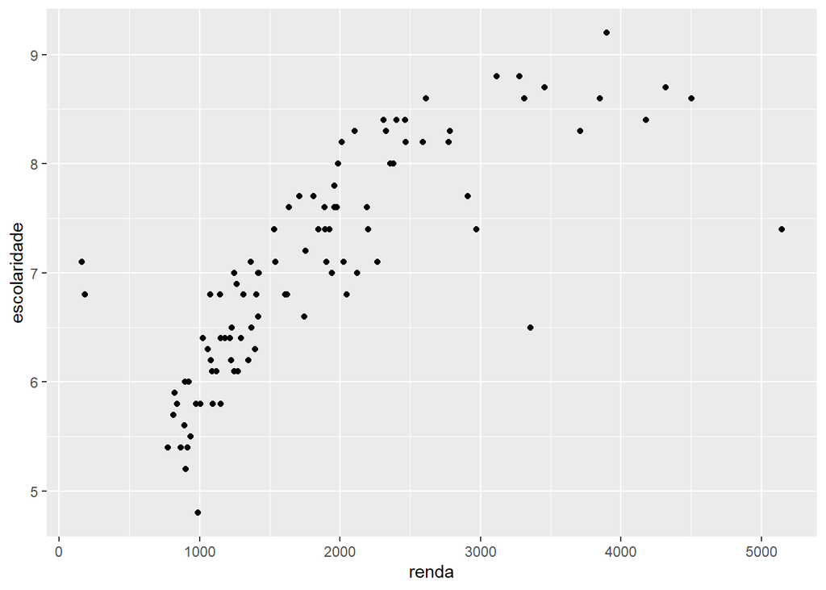

```r
ggplot(atlas_ambiental) +
  geom_point(aes(x = renda, y = escolaridade))
```

Estratificando informações - o uso do argumento size:

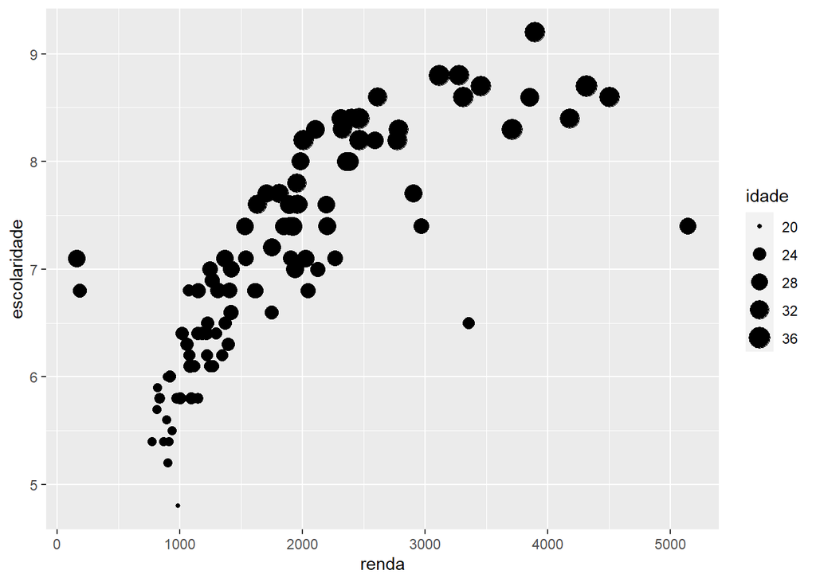

```r
ggplot(atlas_ambiental) +
  geom_point(aes(x = renda, y = escolaridade, size = idade))
```

Estratificando informações - o uso do argumento color:

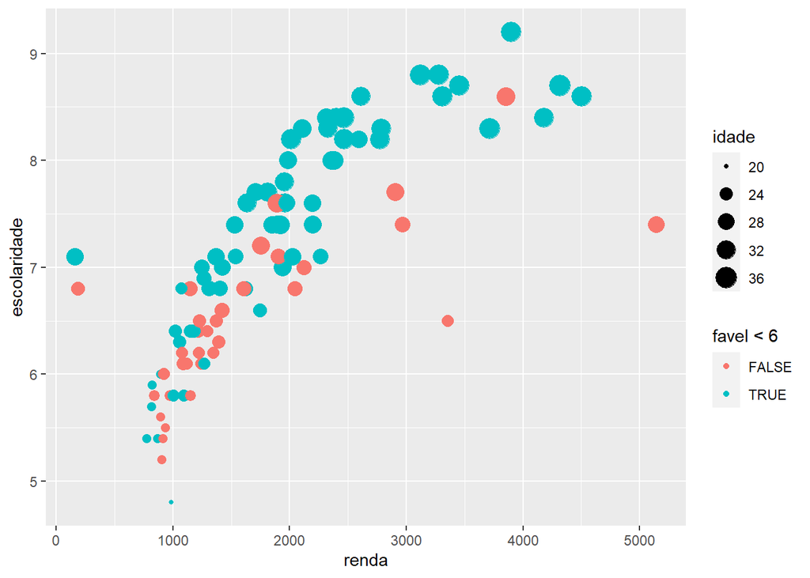

```r
ggplot(atlas_ambiental) +
  geom_point(aes(x = renda, y = escolaridade,
                 size = idade, color = favel < 6))
```

Estratificando informações - o uso do argumento shape:

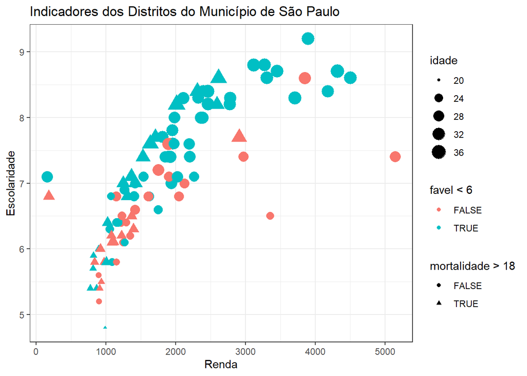

```r
ggplot(atlas_ambiental) +
  geom_point(aes(x = renda, y = escolaridade,
                 size = idade, color = favel < 6,
                 shape = mortalidade > 18)) +
  labs(title = "Indicadores dos Distritos do Município de São Paulo",
       x = "Renda",
       y = "Escolaridade") +
  theme_bw()
```

Traçando uma linha de tendências:

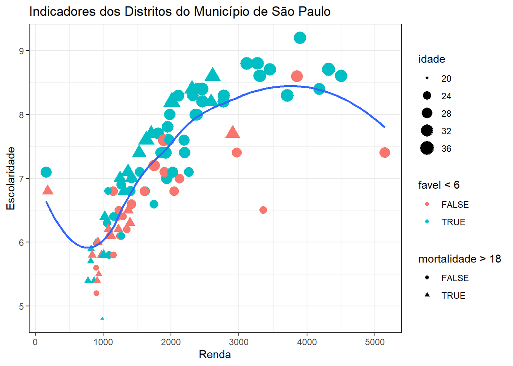

```r
ggplot(atlas_ambiental) +
  geom_point(aes(x = renda, y = escolaridade,
                 size = idade, color = favel < 6,
                 shape = mortalidade > 18)) +
  geom_smooth(aes(x = renda, y = escolaridade),
              method = "loess", se = FALSE) +
  labs(title = "Indicadores dos Distritos do Município de São Paulo",
       x = "Renda",
       y = "Escolaridade") +
  theme_bw()
```

Aproveitando o assunto “tendências”, vamos seguir explorando as capacidades do R com uma nova base de dados sobre a corrupção no mundo (Fisman & Miguel, 2007):

```r
load("fisman_miguel.RData")
```

Notem que seria interessante plotar, por exemplo, o número de violações de trânsito em função do índice de corrupção do país. Vamos tentar?

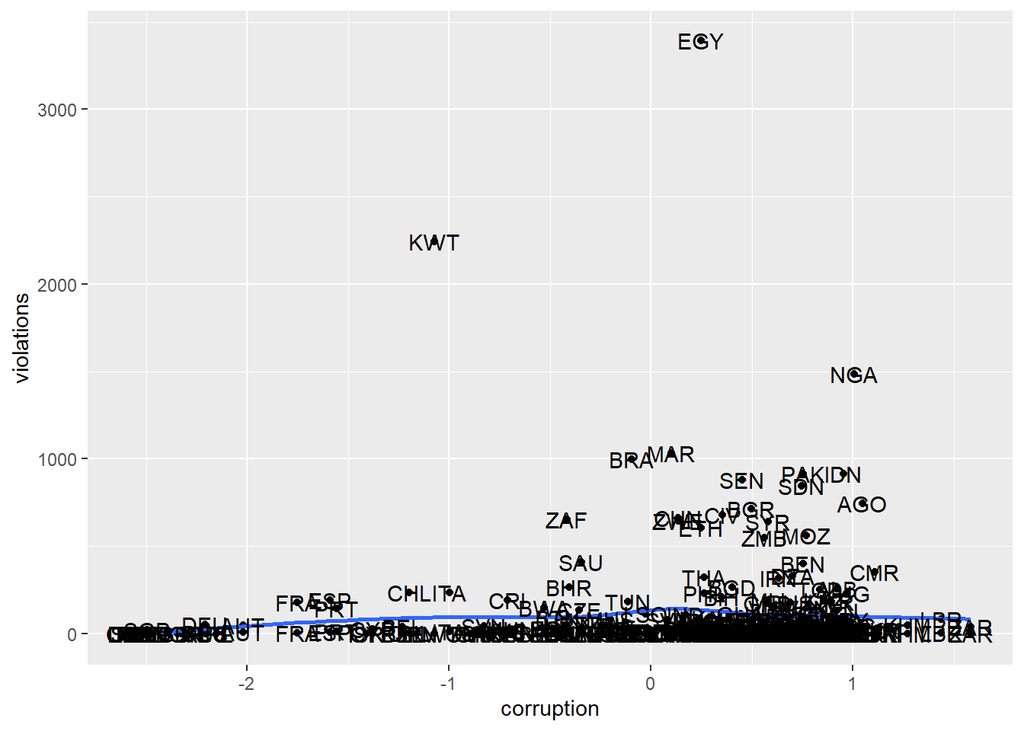

```r
ggplot(fisman_miguel) +
  geom_point(aes(x = corruption, y = violations)) +
  geom_smooth(aes(x = corruption, y = violations),
              se = FALSE,
              method = "loess") +
  geom_text(aes(x = corruption, y = violations, label = code))
```

Note que há dois problemas principais: 1) Há muitos países sem violações reportadas, ou com um baixo número de violações, e países com um número alto de violações reportadas, o que deixaria o gráfico com problemas de escala; 2) Haveria uma dupla contagem, porque os países foram verificados antes e depois da imposição da nova lei de NY.

Vamos tentar mitigar o primeiro problema, padronizando os valores da variável violations

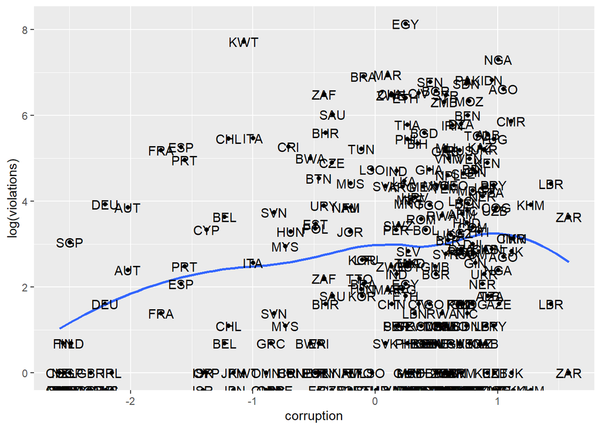

```r
ggplot(fisman_miguel) +
  geom_point(aes(x = corruption, y = log(violations))) +
  geom_smooth(aes(x = corruption, y = log(violations)),
              se = F,
              method = "loess") +
  geom_text(aes(x = corruption, y = log(violations), label = code))
```

Agora, podemos tentar mitigar o segundo problema com alguma função de facet:

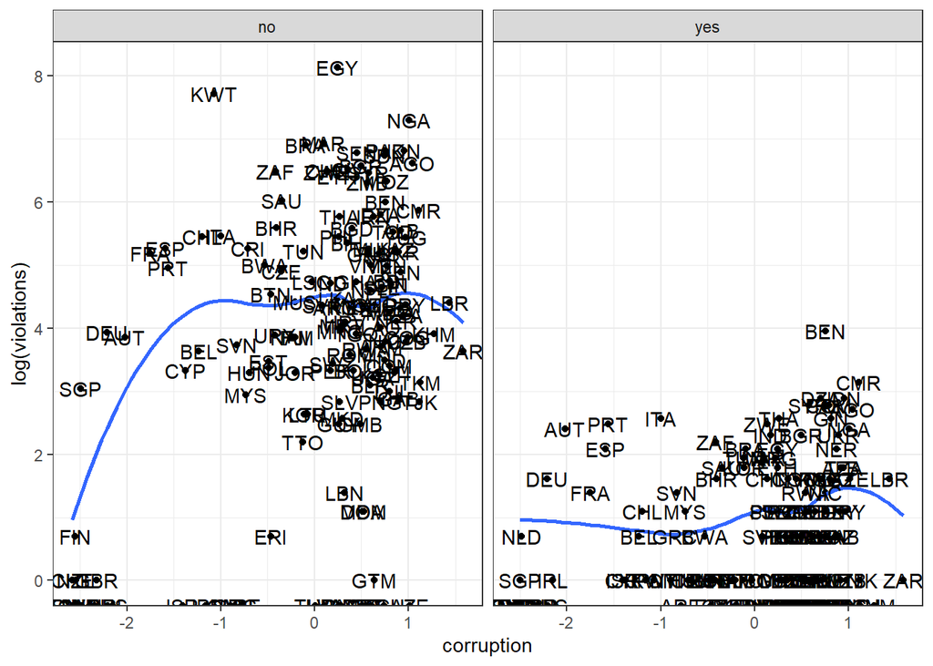

```r
ggplot(fisman_miguel) +
  geom_point(aes(x = corruption, y = log(violations))) +
  geom_smooth(aes(x = corruption, y = log(violations)),
              se = F,
              method = "loess") +
  geom_text(aes(x = corruption, y = log(violations), label = code)) +
  facet_wrap(~post) +
  theme_bw()
```

Note um terceiro problema não identificado anteriormente: a sobreposição de labels. Podemos tentar resolver a situação com a função geom_text_repel(), do pacote ggrepel:

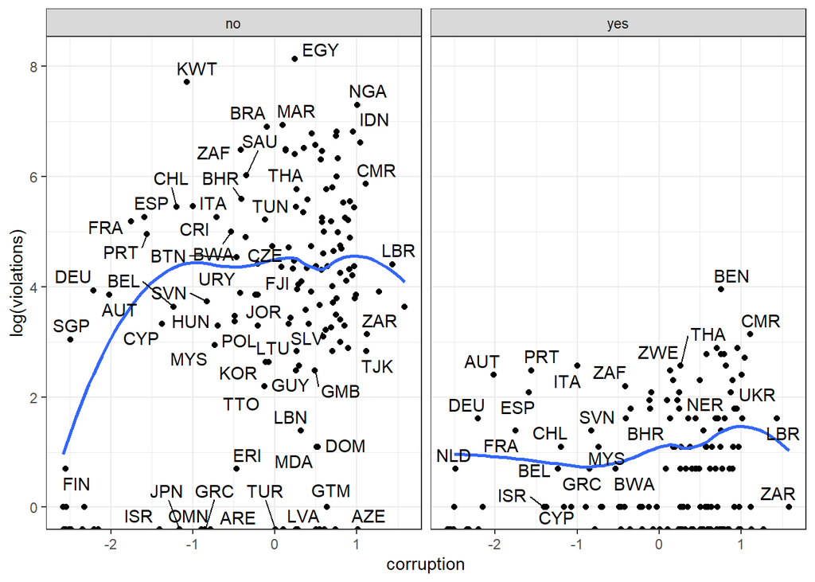

```r
ggplot(fisman_miguel) +
  geom_point(aes(x = corruption, y = log(violations))) +
  geom_smooth(aes(x = corruption, y = log(violations)),
              se = F, method = "loess") +
  geom_text_repel(aes(x = corruption, y = log(violations), label = code)) +
  facet_wrap(~post) +
  theme_bw()
```

# Gráfico de Linhas

Para os nossos gráficos de linhas, vamos utilizar dados da atual pandemia no Brasil, Índia, Rússia e Estados Unidos da América:

```r
load("covid_110521.RData")
```

Aplicando a sintaxe básica do ggplot2:

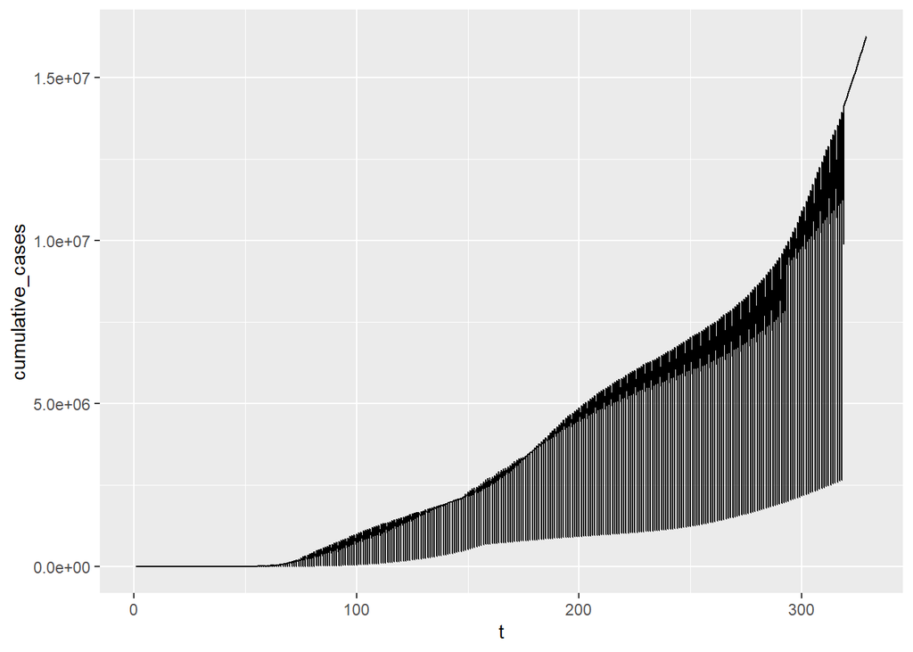

```r
ggplot(covid_110521) +
  geom_line(aes(x = t, y = cumulative_cases))
```

Note que não informamos para o ggplot2 que cada linha deveria representar um país. Assim:

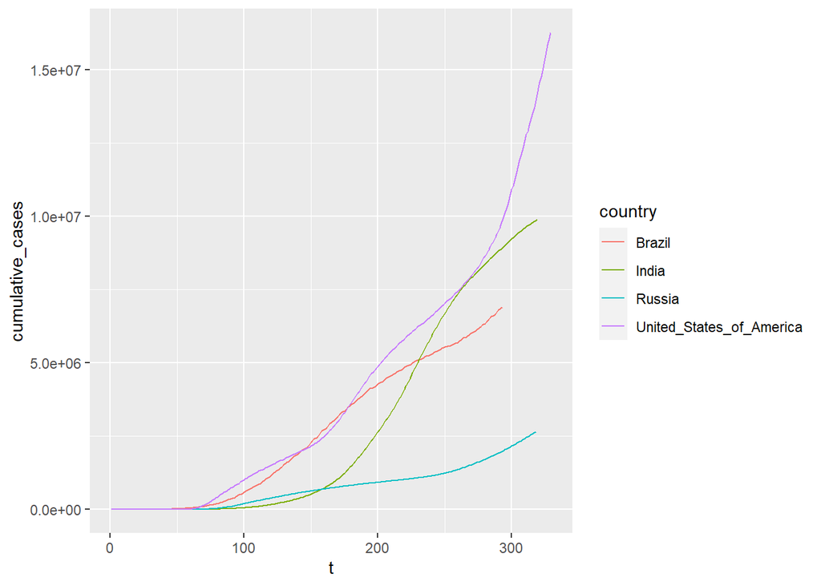

```r
ggplot(covid_110521) +
  geom_line(aes(x = t, y = cumulative_cases, color = country))
```

Adicionando informações e deixando o gráfico mais elegante:

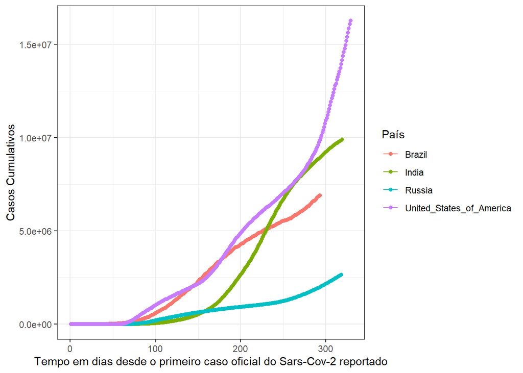

```r
ggplot(covid_110521) +
  geom_line(aes(x = t, y = cumulative_cases, color = country)) +
  geom_point(aes(x = t, y = cumulative_cases, color = country)) +
  labs(x = "Tempo em dias desde o primeiro caso oficial do Sars-Cov-2 reportado",
       y = "Casos Cumulativos",
       color = "País") +
  theme_bw()
```

O gráfico anterior poderia ser mais informativo, visto que, por exemplo, compara países com tamanhos populacionais distintos. Portanto, a magnitude das infecções também é distinta. Uma possibilidade de suavização da situação poderia ser a padronização da variável ‘cumulative_cases’. No gráfico a seguir, padronizamos os casos cumulativos de cada país numa escala log10:

```r
covid_110521["log_ccases"] <- log10(covid_110521$cumulative_cases)
```

O gráfico resultante é o seguinte:

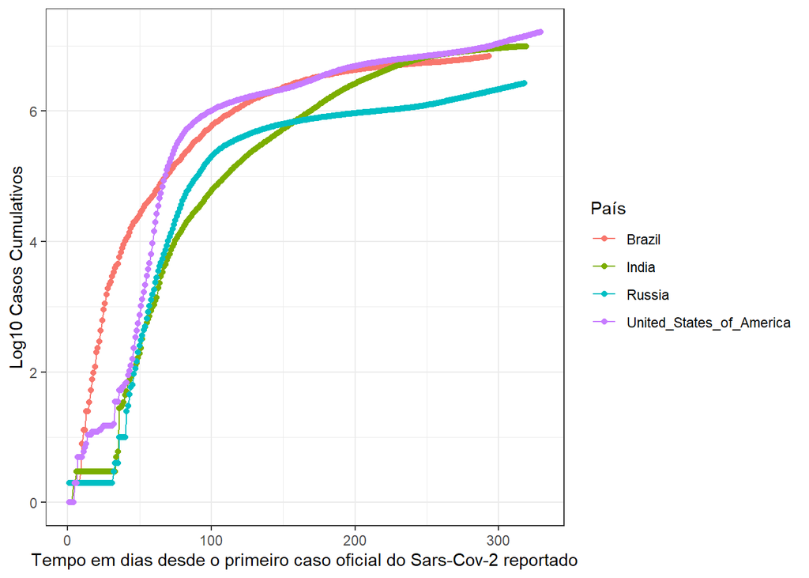

```r
ggplot(covid_110521) +
  geom_line(aes(x = t, y = log_ccases, color = country)) +
  geom_point(aes(x = t, y = log_ccases, color = country)) +
  labs(x = "Tempo em dias desde o primeiro caso oficial do Sars-Cov-2 reportado",
       y = "Log10 Casos Cumulativos",
       color = "País") +
  theme_bw()
```

Por mais que dê para se extrair alguns insights interessantes do gráfico anterior, alguém poderia dizer que seria melhor, por exemplo, utilizar uma proporção da população infectada em razão do tempo passado:

```r
covid_110521["pop_ccases"] <- covid_110521$cumulative_cases /
  covid_110521$pop
```